# Practical Machine Learning

Dimitra Kotsila

August 1, 2018

## Introduction

#### Human Activity Recognition Project

Using devices such as *Jawbone Up*, *Nike FuelBand*, and *Fitbit* it is now possible to collect a large amount of data about personal activity relatively inexpensively. These type of devices are part of the quantified self movement. One thing that people regularly do is quantify how much of a particular activity they do, but they rarely quantify how well they do it. The goal of this project is to predict the manner in which people did the exercise. For that, 6 participants were asked to perform barbell lifts correctly and incorrectly in 5 different ways. Data from accelerometers on the belt, forearm, arm, and dumbell of all participants will be used.

## Data Preparation

### Load Libraries

```r
library(caret)
library(rpart)
library(rpart.plot)
library(RColorBrewer)
library(rattle)
library(randomForest)
library(knitr)
#library(e1071)
```

### Load Data

```r
trainUrl <-"https://d396qusza40orc.cloudfront.net/predmachlearn/pml-training.csv"
testUrl <- "https://d396qusza40orc.cloudfront.net/predmachlearn/pml-testing.csv"

train_data <- read.csv(url(trainUrl), na.strings = c("NA", ""))
test_data <- read.csv(url(testUrl), na.strings = c("NA", ""))


dim(train_data)
```

```
## [1] 19622   160
```

```r
dim(test_data)
```

```
## [1]  20 160
```

So, train dataset has 19622 rows and 160 variables and test dataset has 20 rows and 160 variables.

### Clean datasets

- Remove variables with NA values
- Check if train and test datasets have the same variables
- Remove the first 7 variables since they have little predictiong power

```r
train_data_final <- train_data[, colSums(is.na(train_data)) == 0]
test_data_final <- test_data[, colSums(is.na(test_data)) == 0]

# Find variables that are different in two datasets (the difference will be in classe variable)
diff <- names(train_data_final)[names(train_data_final) != names(test_data_final)]
diff
```

```
## [1] "classe"
```

```r
# Remove useless variables
train_data_final <- train_data_final[, -c(1:7)]
test_data_final <- test_data_final[, -c(1:7)]
```

### Split data

We split train dataset into train_sub (80%) and test_sub (20%) in order to validate the model (cross validation).

```r
set.seed(414243)
valid_train <- createDataPartition(train_data_final$classe, p = 0.8, list = FALSE)
train_sub <- train_data_final[valid_train, ]
test_sub <- train_data_final[-valid_train, ]
```

## Prediction Models

### Decision trees

We set k = 8 in k-fold cross validation.

```r
control <- trainControl(method = "cv", number = 8)
model_decision_tree <- train(classe ~ ., data = train_sub, method = "rpart",
                             trControl = control)

model_decision_tree
```

```
## CART
##
## 15699 samples
##    52 predictor
##     5 classes: 'A', 'B', 'C', 'D', 'E'
##
## No pre-processing
## Resampling: Cross-Validated (8 fold)
## Summary of sample sizes: 13736, 13737, 13737, 13737, 13737, 13738, ...
## Resampling results across tuning parameters:
##
##   cp          Accuracy   Kappa
##   0.03168669  0.5144244  0.36631361
##   0.06147456  0.4602919  0.28321701
##   0.11437472  0.3335388  0.07506412
##
## Accuracy was used to select the optimal model using the largest value.
## The final value used for the model was cp = 0.03168669.
```

[figure not shown]

```r
fancyRpartPlot(model_decision_tree$finalModel)
```

```r
# predict outcomes using validation set
predict_decision_tree <- predict(model_decision_tree, test_sub)
# Show prediction result
(conf_decision_tree <- confusionMatrix(test_sub$classe, predict_decision_tree))
```

```
## Confusion Matrix and Statistics
##
##           Reference
## Prediction    A    B    C    D    E
##          A 1014   17   83    0    2
##          B  334  227  198    0    0
##          C  335   20  329    0    0
##          D  274  110  259    0    0
##          E   90   99  198    0  334
##
## Overall Statistics
##
##                Accuracy : 0.4853
##                  95% CI : (0.4696, 0.5011)
##     No Information Rate : 0.5218
##     P-Value [Acc > NIR] : 1
##
##                   Kappa : 0.3273
##  Mcnemar's Test P-Value : NA
##
## Statistics by Class:
##
##                      Class: A Class: B Class: C Class: D Class: E
## Sensitivity            0.4954  0.47992  0.30834       NA  0.99405
## Specificity            0.9456  0.84580  0.87570   0.8361  0.89211
## Pos Pred Value         0.9086  0.29908  0.48099       NA  0.46325
## Neg Pred Value         0.6320  0.92225  0.77215       NA  0.99938
## Prevalence             0.5218  0.12057  0.27199   0.0000  0.08565
## Detection Rate         0.2585  0.05786  0.08386   0.0000  0.08514
## Detection Prevalence   0.2845  0.19347  0.17436   0.1639  0.18379
## Balanced Accuracy      0.7205  0.66286  0.59202       NA  0.94308
```

As we see on the confusion matrix, the accuracy rate is close to 0.5. Thus, the out-of-sample error rate is 0.5. The decision tree model does not predict our sample data so well.

## Random Forest

```r
model_random_forest <- train(classe ~ ., data = train_sub, method = "rf",
                             trControl = control)

model_random_forest
```

```
## Random Forest
##
## 15699 samples
##    52 predictor
##     5 classes: 'A', 'B', 'C', 'D', 'E'
##
## No pre-processing
## Resampling: Cross-Validated (8 fold)
## Summary of sample sizes: 13739, 13736, 13737, 13735, 13737, 13738, ...
## Resampling results across tuning parameters:
##
##   mtry  Accuracy   Kappa
##    2    0.9931200  0.9912967
##   27    0.9924200  0.9904111
##   52    0.9856041  0.9817874
##
## Accuracy was used to select the optimal model using the largest value.
## The final value used for the model was mtry = 2.
```

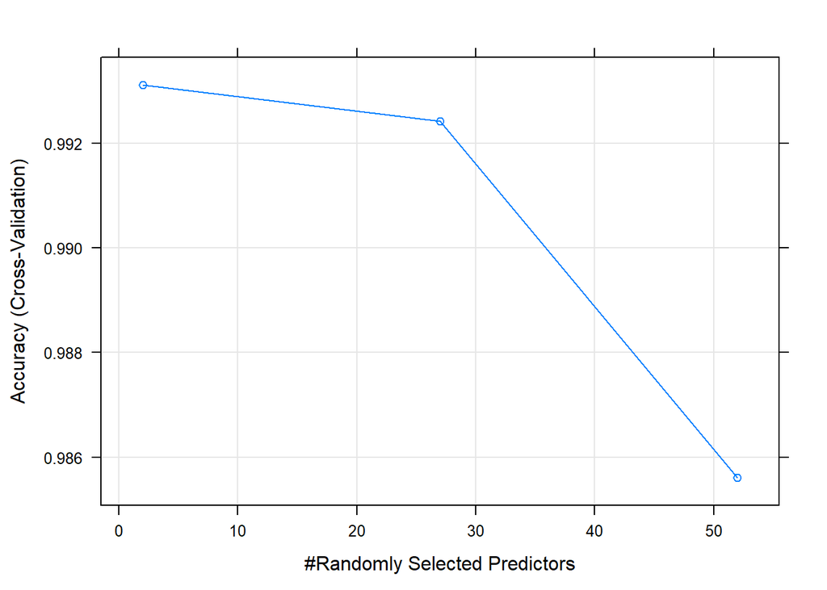

```r
plot(model_random_forest)
```

```r
# predict outcomes using validation set
predict_random_forest <- predict(model_random_forest, test_sub)
# Show prediction result
(conf_random_forest <- confusionMatrix(test_sub$classe, predict_random_forest))
```

```
## Confusion Matrix and Statistics
##
##           Reference
## Prediction    A    B    C    D    E
##          A 1115    1    0    0    0
##          B    5  753    1    0    0
##          C    0    3  681    0    0
##          D    0    0   10  631    2
##          E    0    0    1    1  719
##
## Overall Statistics
##
##                Accuracy : 0.9939
##                  95% CI : (0.9909, 0.9961)
##     No Information Rate : 0.2855
##     P-Value [Acc > NIR] : < 2.2e-16
##
##                   Kappa : 0.9923
##  Mcnemar's Test P-Value : NA
##
## Statistics by Class:
##
##                      Class: A Class: B Class: C Class: D Class: E
## Sensitivity            0.9955   0.9947   0.9827   0.9984   0.9972
## Specificity            0.9996   0.9981   0.9991   0.9964   0.9994
## Pos Pred Value         0.9991   0.9921   0.9956   0.9813   0.9972
## Neg Pred Value         0.9982   0.9987   0.9963   0.9997   0.9994
## Prevalence             0.2855   0.1930   0.1767   0.1611   0.1838
## Detection Rate         0.2842   0.1919   0.1736   0.1608   0.1833
## Detection Prevalence   0.2845   0.1935   0.1744   0.1639   0.1838
## Balanced Accuracy      0.9976   0.9964   0.9909   0.9974   0.9983
```

The Accurancy of Random Forest is very high 0.9939.

## Prediction on Test dataset

The Random Forest model has higher accurancy. So we predict the classe of test data set.

```r
(predict(model_random_forest, test_data_final))
```

```
##  [1] B A B A A E D B A A B C B A E E A B B B
## Levels: A B C D E
```